# Segmenting and Clustering Neighborhoods in Toronto

## Introduction

In this assignment, we will be required to explore, segment, and cluster the neighborhoods in the city of Toronto based on the postalcode and borough information.

For the Toronto neighborhood data, a Zipcodeonline page exists that has all the information we need to explore and cluster the neighborhoods in Toronto. We will be required to scrape the Zipcodeonline page and wrangle the data, clean it, and then read it into a pandas dataframe so that it is in a structured format like the New York dataset.

Once the data is in a structured format, we can analysis the dataset to explore and cluster the neighborhoods in the city of Toronto.

https://www.zipcodesonline.com/2020/06/postal-code-of-toronto-in-2020.html

1. Scrape and Explore Dataset 2. Explore Neighborhoods in Toronto 3. Analyze Each Neighborhood 4. Cluster Neighborhoods 5. Examine Clusters

Before we get the data and start exploring it, let's download all the dependencies that we will need.

```python
from bs4 import BeautifulSoup # this module helps in web scrapping.
import itertools

import numpy as np # library to handle data in a vectorized manner

import pandas as pd # library for data analsysis
pd.set_option('display.max_columns', None)
pd.set_option('display.max_rows', None)

import json # library to handle JSON files

#!conda install -c conda-forge geopy --yes # uncomment this line if you haven't completed the Foursquare API lab
from geopy.geocoders import Nominatim # convert an address into latitude and longitude values

import requests # library to handle requests
from pandas.io.json import json_normalize # tranform JSON file into a pandas dataframe

# Matplotlib and associated plotting modules
import matplotlib.cm as cm
import matplotlib.colors as colors

# import k-means from clustering stage
from sklearn.cluster import KMeans

#!conda install -c conda-forge folium=0.5.0 --yes # uncomment this line if you haven't completed the Foursquare API lab
import folium # map rendering library

print('Libraries imported.')
```

```
Libraries imported.
```

## 1. Scrape and Explore Dataset

```python
url = 'https://www.zipcodesonline.com/2020/06/postal-code-of-toronto-in-2020.html'
print(url)
```

```
https://www.zipcodesonline.com/2020/06/postal-code-of-toronto-in-2020.html
```

```python
dataframe_list = pd.read_html(url, flavor='bs4')
len(dataframe_list)
```

```
2
```

#### Transform the data into a *pandas* dataframe

```python
toronto= dataframe_list[1]
toronto.head()
```

|  | 0 | 1 | 2 | 3 |
| --- | --- | --- | --- | --- |
| 0 | SL. NO. | NEIGHBOURHOOD | POSTAL CODES | DISTRICT |
| 1 | NaN | NaN | NaN | NaN |
| 2 | 1 | Adelaide | M5H | Downtown Toronto |
| 3 | 2 | Agincourt North | M1V | Scarborough |
| 4 | 3 | Agincourt | M1S | Scarborough |

#### Load and explore the data

```python
headers = ['SL. NO.','NEIGHBOURHOOD','POSTAL CODES','BOROUGH']
```

```python
toronto.columns = headers
toronto.drop(index=[0,1],inplace=True,axis=0)
toronto.set_index('SL. NO.',inplace=True)
```

Let's take a quick look at the data.

```python
toronto.head()
```

| SL. NO. | NEIGHBOURHOOD | POSTAL CODES | BOROUGH |
| --- | --- | --- | --- |
| 1 | Adelaide | M5H | Downtown Toronto |
| 2 | Agincourt North | M1V | Scarborough |
| 3 | Agincourt | M1S | Scarborough |
| 4 | Albion Gardens | M9V | Etobicoke |
| 5 | Alderwood | M8W | Etobicoke |

```python
print('The dataframe has {} boroughs and {} neighborhoods.'.format(
        len(toronto['BOROUGH'].unique()),
        toronto.shape[0]
    )
)
```

```
The dataframe has 11 boroughs and 205 neighborhoods.
```

```python
Geospatial_Coordinates = pd.read_csv('Geospatial_Coordinates.csv')
Geospatial_Coordinates.head()
```

|  | Postal Code | Latitude | Longitude |
| --- | --- | --- | --- |
| 0 | M1B | 43.806686 | -79.194353 |
| 1 | M1C | 43.784535 | -79.160497 |
| 2 | M1E | 43.763573 | -79.188711 |
| 3 | M1G | 43.770992 | -79.216917 |
| 4 | M1H | 43.773136 | -79.239476 |

```python
toronto_data = toronto.merge(Geospatial_Coordinates,left_on='POSTAL CODES', right_on='Postal Code')
toronto_data.drop('Postal Code',axis=1,inplace=True)
```

```python
address = 'Toronto, ON'

geolocator = Nominatim(user_agent="ny_explorer")
location = geolocator.geocode(address)
latitude = location.latitude
longitude = location.longitude
print('The geograpical coordinate of Toronto are {}, {}.'.format(latitude, longitude))
```

```
The geograpical coordinate of Toronto are 43.6534817, -79.3839347.
```

Quickly examine the resulting dataframe.

```python
toronto_data.head()
```

|  | NEIGHBOURHOOD | POSTAL CODES | BOROUGH | Latitude | Longitude |
| --- | --- | --- | --- | --- | --- |
| 0 | Adelaide | M5H | Downtown Toronto | 43.650571 | -79.384568 |
| 1 | Richmond | M5H | Downtown Toronto | 43.650571 | -79.384568 |
| 2 | Agincourt North | M1V | Scarborough | 43.815252 | -79.284577 |
| 3 | L'Amoreaux East | M1V | Scarborough | 43.815252 | -79.284577 |
| 4 | Milliken | M1V | Scarborough | 43.815252 | -79.284577 |

```python
toronto_data.tail()
```

|  | NEIGHBOURHOOD | POSTAL CODES | BOROUGH | Latitude | Longitude |
| --- | --- | --- | --- | --- | --- |
| 197 | Westmount | M9P | Etobicoke | 43.696319 | -79.532242 |
| 198 | Weston | M9N | York | 43.706876 | -79.518188 |
| 199 | Woburn | M1G | Scarborough | 43.770992 | -79.216917 |
| 200 | Woodbine Heights | M4C | East York | 43.695344 | -79.318389 |
| 201 | York Mills West | M2P | North York | 43.752758 | -79.400049 |

#### Create a map of Toronto with neighborhoods superimposed on top.

```python
# create map of New York using latitude and longitude values
map_toronto = folium.Map(location=[latitude, longitude], zoom_start=10)

# add markers to map
for lat, lng, borough, toronto_list in zip(toronto_data['Latitude'], toronto_data['Longitude'], toronto_data['BOROUGH'],
                                           toronto_data['NEIGHBOURHOOD']):
    label = '{}, {}'.format(toronto_list, borough)
    label = folium.Popup(label, parse_html=True)
    folium.CircleMarker(
        [lat, lng],
        radius=7,
        popup=label,
        color='blue',
        fill=True,
        fill_color='#3186cc',
        fill_opacity=0.1,
        parse_html=False).add_to(map_toronto)

map_toronto
```

Make this Notebook Trusted to load map: File -> Trust Notebook

[interactive chart not shown]

#### Define Foursquare Credentials and Version

```python
CLIENT_ID = '4B3ATA5MMVEF3LUH5IXFYZLIYLOGGRJ2SNRMVYVVLLGNDSI0' # your Foursquare ID
CLIENT_SECRET = '' # your Foursquare Secret
VERSION = '20180605' # Foursquare API version
LIMIT = 100 # A default Foursquare API limit value

print('Your credentails:')
print('CLIENT_ID: ' + CLIENT_ID)
print('CLIENT_SECRET:' + CLIENT_SECRET)
```

[output not shown]

#### Let's explore the first neighborhood in our dataframe.

Get the neighborhood's name.

```python
toronto_data.loc[0, 'NEIGHBOURHOOD']
```

```
'Adelaide'
```

Get the neighborhood's latitude and longitude values.

```python
neighborhood_latitude = toronto_data.loc[0, 'Latitude'] # neighborhood latitude value
neighborhood_longitude = toronto_data.loc[0, 'Longitude'] # neighborhood longitude value

neighborhood_name = toronto_data.loc[0, 'NEIGHBOURHOOD'] # neighborhood name

print('Latitude and longitude values of {} are {}, {}.'.format(neighborhood_name,
                                                               neighborhood_latitude,
                                                               neighborhood_longitude))
```

```
Latitude and longitude values of Adelaide are 43.65057120000001, -79.3845675.
```

#### Now, let's get the top 100 venues that are in Adelaide within a radius of 500 meters.

```python
# type your answer here
LIMIT = 100 # limit of number of venues returned by Foursquare API
radius = 500 # define radius

url = 'https://api.foursquare.com/v2/venues/explore?&client_id={}&client_secret={}&v={}&ll={},{}&radius={}&limit={}'.format(
    CLIENT_ID,
    CLIENT_SECRET,
    VERSION,
    neighborhood_latitude,
    neighborhood_longitude,
    radius,
    LIMIT)
url # display URL
```

```
'https://api.foursquare.com/v2/venues/explore?&client_id=4B3ATA5MMVEF3LUH5IXFYZLIYLOGGRJ2SNRMVYVVLLGNDSI0&client_secret=WFJ3KNFXAC4AXM13CUMAKLTJ543UZSG1N0RMJJ0QJBAB1XJT&v=20180605&ll=43.65057120000001,-79.3845675&radius=500&limit=100'
```

Send the GET request and examine the resutls

```python
results = requests.get(url).json()
results
```

[output not shown]

[output cut: 3002 more lines]

[output not shown]

From the Foursquare lab in the previous module, we know that all the information is in the *items* key. Before we proceed, let's borrow the **get_category_type** function from the Foursquare lab.

```python
# function that extracts the category of the venue
def get_category_type(row):
    try:
        categories_list = row['categories']
    except:
        categories_list = row['venue.categories']

    if len(categories_list) == 0:
        return None
    else:
        return categories_list[0]['name']
```

Now we are ready to clean the json and structure it into a *pandas* dataframe.

```python
def getNearbyVenues(names, latitudes, longitudes, radius=500):

    venues_list=[]
    for name, lat, lng in zip(names, latitudes, longitudes):
        print(name)

        # create the API request URL
        url = 'https://api.foursquare.com/v2/venues/explore?&client_id={}&client_secret={}&v={}&ll={},{}&radius={}&limit={}'.format(
            CLIENT_ID,
            CLIENT_SECRET,
            VERSION,
            lat,
            lng,
            radius,
            LIMIT)

        # make the GET request
        results = requests.get(url).json()["response"]['groups'][0]['items']

        # return only relevant information for each nearby venue
        venues_list.append([(
            name,
            lat,
            lng,
            v['venue']['name'],
            v['venue']['location']['lat'],
            v['venue']['location']['lng'],
            v['venue']['categories'][0]['name']) for v in results])

    nearby_venues = pd.DataFrame([item for venue_list in venues_list for item in venue_list])
    nearby_venues.columns = ['Neighborhood',
                  'Neighborhood Latitude',
                  'Neighborhood Longitude',
                  'Venue',
                  'Venue Latitude',
                  'Venue Longitude',
                  'Venue Category']

    return(nearby_venues)
```

```python
venues = results['response']['groups'][0]['items']

nearby_venues = pd.json_normalize(venues) # flatten JSON

# filter columns
filtered_columns = ['venue.name', 'venue.categories', 'venue.location.lat', 'venue.location.lng']
nearby_venues =nearby_venues.loc[:, filtered_columns]

# filter the category for each row
nearby_venues['venue.categories'] = nearby_venues.apply(get_category_type, axis=1)

# clean columns
nearby_venues.columns = [col.split(".")[-1] for col in nearby_venues.columns]

nearby_venues.head()
```

|  | name | categories | lat | lng |
| --- | --- | --- | --- | --- |
| 0 | Nathan Phillips Square | Plaza | 43.652270 | -79.383516 |
| 1 | M Square Coffee Co | Coffee Shop | 43.651218 | -79.383555 |
| 2 | Four Seasons Centre for the Performing Arts | Concert Hall | 43.650592 | -79.385806 |
| 3 | Adelaide Club Toronto | Gym / Fitness Center | 43.649279 | -79.381921 |
| 4 | John & Sons Oyster House | Seafood Restaurant | 43.650656 | -79.381613 |

And how many venues were returned by Foursquare?

```python
print('{} venues were returned by Foursquare.'.format(nearby_venues.shape[0]))
```

```
100 venues were returned by Foursquare.
```

## 2. Explore Neighborhoods in Toronto

#### Let's create a function to repeat the same process to all the neighborhoods in Toronto

#### Now the code below will run the above function on each neighborhood and create a new dataframe called _toronto*venues*.

```python
toronto_venues = getNearbyVenues(names=toronto_data['NEIGHBOURHOOD'],
                                   latitudes=toronto_data['Latitude'],
                                   longitudes=toronto_data['Longitude']
                                  )
```

```
Adelaide
Richmond
Agincourt North
L'Amoreaux East
Milliken
Steeles East
Agincourt
Albion Gardens
Beaumond Heights
Humbergate
Jamestown
Mount Olive
Silverstone
South Steeles
Thistletown
Alderwood
Long Branch
Bathurst Manor
Downsview North
Wilson Heights
Bathurst Quay
CN Tower
Harbourfront West
Island airport
King and Spadina
Railway Lands
South Niagara
Bayview Village
Bedford Park, ,
Lawrence Manor East
Berczy Park
Birch Cliff
Cliffside West
Bloordale Gardens
Eringate
Markland Wood
Old Burnhamthorpe
Broadview North
East Toronto
Brockton
```

[output cut: 147 more lines]

```
Scarborough Village
Silver Hills
York Mills
St. James Town
Stn A PO Boxes
Studio District
The Beaches
Thorncliffe Park
Upper Rouge
Victoria Village
Westmount
Weston
Woburn
Woodbine Heights
York Mills West
```

#### Let's check the size of the resulting dataframe

```python
print(toronto_venues.shape)
toronto_venues.head()
```

```
(3834, 7)
```

|  | Neighborhood | Neighborhood Latitude | Neighborhood Longitude | Venue | Venue Latitude | Venue Longitude | Venue Category |
| --- | --- | --- | --- | --- | --- | --- | --- |
| 0 | Adelaide | 43.650571 | -79.384568 | Nathan Phillips Square | 43.652270 | -79.383516 | Plaza |
| 1 | Adelaide | 43.650571 | -79.384568 | M Square Coffee Co | 43.651218 | -79.383555 | Coffee Shop |
| 2 | Adelaide | 43.650571 | -79.384568 | Four Seasons Centre for the Performing Arts | 43.650592 | -79.385806 | Concert Hall |
| 3 | Adelaide | 43.650571 | -79.384568 | Adelaide Club Toronto | 43.649279 | -79.381921 | Gym / Fitness Center |
| 4 | Adelaide | 43.650571 | -79.384568 | John & Sons Oyster House | 43.650656 | -79.381613 | Seafood Restaurant |

Let's check how many venues were returned for each neighborhood

```python
toronto_venues.groupby('Neighborhood').count()
```

| Neighborhood | Neighborhood Latitude | Neighborhood Longitude | Venue | Venue Latitude | Venue Longitude | Venue Category |
| --- | --- | --- | --- | --- | --- | --- |
| Adelaide | 100 | 100 | 100 | 100 | 100 | 100 |
| Agincourt | 4 | 4 | 4 | 4 | 4 | 4 |
| Agincourt North | 3 | 3 | 3 | 3 | 3 | 3 |
| Albion Gardens | 9 | 9 | 9 | 9 | 9 | 9 |
| Alderwood | 7 | 7 | 7 | 7 | 7 | 7 |
| Bathurst Manor | 19 | 19 | 19 | 19 | 19 | 19 |
| Bathurst Quay | 15 | 15 | 15 | 15 | 15 | 15 |
| Bayview Village | 4 | 4 | 4 | 4 | 4 | 4 |
| Beaumond Heights | 9 | 9 | 9 | 9 | 9 | 9 |
| Bedford Park, , | 23 | 23 | 23 | 23 | 23 | 23 |
| Berczy Park | 46 | 46 | 46 | 46 | 46 | 46 |
| Birch Cliff | 5 | 5 | 5 | 5 | 5 | 5 |
| Bloordale Gardens | 7 | 7 | 7 | 7 | 7 | 7 |
| Broadview North | 4 | 4 | 4 | 4 | 4 | 4 |
| Brockton | 23 | 23 | 23 | 23 | 23 | 23 |
| Business reply mail Processing Centre | 17 | 17 | 17 | 17 | 17 | 17 |
| CN Tower | 15 | 15 | 15 | 15 | 15 | 15 |
| Cabbagetown | 36 | 36 | 36 | 36 | 36 | 36 |
| Caledonia Fairbanks | 4 | 4 | 4 | 4 | 4 | 4 |
| Canada Post Gateway Processing Centre | 13 | 13 | 13 | 13 | 13 | 13 |
| Cedarbrae | 8 | 8 | 8 | 8 | 8 | 8 |
| Central Bay Street | 61 | 61 | 61 | 61 | 61 | 61 |
| Chinatown | 59 | 59 | 59 | 59 | 59 | 59 |
| Christie | 15 | 15 | 15 | 15 | 15 | 15 |
| Church and Wellesley | 69 | 69 | 69 | 69 | 69 | 69 |
| Clairlea | 10 | 10 | 10 | 10 | 10 | 10 |
| Clarks Corners | 11 | 11 | 11 | 11 | 11 | 11 |
| Cliffcrest | 3 | 3 | 3 | 3 | 3 | 3 |
| Cliffside | 3 | 3 | 3 | 3 | 3 | 3 |
| Cliffside West | 5 | 5 | 5 | 5 | 5 | 5 |

[output cut: 167 more lines]

#### Let's find out how many unique categories can be curated from all the returned venues

```python
print('There are {} uniques categories.'.format(len(toronto_venues['Venue Category'].unique())))
```

```
There are 258 uniques categories.
```

## 3. Analyze Each Neighborhood

```python
# one hot encoding
toronto_onehot = pd.get_dummies(toronto_venues[['Venue Category']], prefix="", prefix_sep="")

# add neighborhood column back to dataframe
toronto_onehot['Neighborhood'] = toronto_venues['Neighborhood']

# move neighborhood column to the first column
fixed_columns = [toronto_onehot.columns[-1]] + list(toronto_onehot.columns[:-1])
toronto_onehot = toronto_onehot[fixed_columns]

toronto_onehot.head()
```

|  | Yoga Studio | Accessories Store | Adult Boutique | Afghan Restaurant | Airport | Airport Food Court | Airport Gate | Airport Lounge | Airport Service | Airport Terminal | American Restaurant | Antique Shop | Aquarium | Art Gallery | Arts & Crafts Store | Asian Restaurant | Athletics & Sports | Auto Garage | Auto Workshop | BBQ Joint | Baby Store | Bagel Shop | Bakery | Bank | Bar | Baseball Field | Baseball Stadium | Basketball Court | Basketball Stadium | … |
| --- | --- | --- | --- | --- | --- | --- | --- | --- | --- | --- | --- | --- | --- | --- | --- | --- | --- | --- | --- | --- | --- | --- | --- | --- | --- | --- | --- | --- | --- | --- |
| 0 | 0 | 0 | 0 | 0 | 0 | 0 | 0 | 0 | 0 | 0 | 0 | 0 | 0 | 0 | 0 | 0 | 0 | 0 | 0 | 0 | 0 | 0 | 0 | 0 | 0 | 0 | 0 | 0 | 0 | … |
| 1 | 0 | 0 | 0 | 0 | 0 | 0 | 0 | 0 | 0 | 0 | 0 | 0 | 0 | 0 | 0 | 0 | 0 | 0 | 0 | 0 | 0 | 0 | 0 | 0 | 0 | 0 | 0 | 0 | 0 | … |
| 2 | 0 | 0 | 0 | 0 | 0 | 0 | 0 | 0 | 0 | 0 | 0 | 0 | 0 | 0 | 0 | 0 | 0 | 0 | 0 | 0 | 0 | 0 | 0 | 0 | 0 | 0 | 0 | 0 | 0 | … |
| 3 | 0 | 0 | 0 | 0 | 0 | 0 | 0 | 0 | 0 | 0 | 0 | 0 | 0 | 0 | 0 | 0 | 0 | 0 | 0 | 0 | 0 | 0 | 0 | 0 | 0 | 0 | 0 | 0 | 0 | … |
| 4 | 0 | 0 | 0 | 0 | 0 | 0 | 0 | 0 | 0 | 0 | 0 | 0 | 0 | 0 | 0 | 0 | 0 | 0 | 0 | 0 | 0 | 0 | 0 | 0 | 0 | 0 | 0 | 0 | 0 | … |

And let's examine the new dataframe size.

```python
toronto_onehot.shape
```

```
(3834, 258)
```

#### Next, let's group rows by neighborhood and by taking the mean of the frequency of occurrence of each category

```python
toronto_grouped = toronto_onehot.groupby('Neighborhood').mean().reset_index()
toronto_grouped.head()
```

|  | Neighborhood | Yoga Studio | Accessories Store | Adult Boutique | Afghan Restaurant | Airport | Airport Food Court | Airport Gate | Airport Lounge | Airport Service | Airport Terminal | American Restaurant | Antique Shop | Aquarium | Art Gallery | Arts & Crafts Store | Asian Restaurant | Athletics & Sports | Auto Garage | Auto Workshop | BBQ Joint | Baby Store | Bagel Shop | Bakery | Bank | Bar | Baseball Field | Baseball Stadium | Basketball Court | … |
| --- | --- | --- | --- | --- | --- | --- | --- | --- | --- | --- | --- | --- | --- | --- | --- | --- | --- | --- | --- | --- | --- | --- | --- | --- | --- | --- | --- | --- | --- | --- |
| 0 | Adelaide | 0.0 | 0.0 | 0.0 | 0.0 | 0.0 | 0.0 | 0.0 | 0.0 | 0.0 | 0.0 | 0.01 | 0.0 | 0.0 | 0.01 | 0.0 | 0.02 | 0.000000 | 0.0 | 0.0 | 0.0 | 0.0 | 0.01 | 0.01 | 0.02 | 0.01 | 0.0 | 0.0 | 0.0 | … |
| 1 | Agincourt | 0.0 | 0.0 | 0.0 | 0.0 | 0.0 | 0.0 | 0.0 | 0.0 | 0.0 | 0.0 | 0.00 | 0.0 | 0.0 | 0.00 | 0.0 | 0.00 | 0.000000 | 0.0 | 0.0 | 0.0 | 0.0 | 0.00 | 0.00 | 0.00 | 0.00 | 0.0 | 0.0 | 0.0 | … |
| 2 | Agincourt North | 0.0 | 0.0 | 0.0 | 0.0 | 0.0 | 0.0 | 0.0 | 0.0 | 0.0 | 0.0 | 0.00 | 0.0 | 0.0 | 0.00 | 0.0 | 0.00 | 0.000000 | 0.0 | 0.0 | 0.0 | 0.0 | 0.00 | 0.00 | 0.00 | 0.00 | 0.0 | 0.0 | 0.0 | … |
| 3 | Albion Gardens | 0.0 | 0.0 | 0.0 | 0.0 | 0.0 | 0.0 | 0.0 | 0.0 | 0.0 | 0.0 | 0.00 | 0.0 | 0.0 | 0.00 | 0.0 | 0.00 | 0.000000 | 0.0 | 0.0 | 0.0 | 0.0 | 0.00 | 0.00 | 0.00 | 0.00 | 0.0 | 0.0 | 0.0 | … |
| 4 | Alderwood | 0.0 | 0.0 | 0.0 | 0.0 | 0.0 | 0.0 | 0.0 | 0.0 | 0.0 | 0.0 | 0.00 | 0.0 | 0.0 | 0.00 | 0.0 | 0.00 | 0.142857 | 0.0 | 0.0 | 0.0 | 0.0 | 0.00 | 0.00 | 0.00 | 0.00 | 0.0 | 0.0 | 0.0 | … |

#### Let's confirm the new size

```python
toronto_grouped.shape
```

```
(197, 258)
```

#### Let's print each neighborhood along with the top 5 most common venues

```python
num_top_venues = 5

for hood in toronto_grouped['Neighborhood']:
    print("----"+hood+"----")
    temp = toronto_grouped[toronto_grouped['Neighborhood'] == hood].T.reset_index()
    temp.columns = ['venue','freq']
    temp = temp.iloc[1:]
    temp['freq'] = temp['freq'].astype(float)
    temp = temp.round({'freq': 2})
    print(temp.sort_values('freq', ascending=False).reset_index(drop=True).head(num_top_venues))
    print('\n')
```

```
----Adelaide----
            venue  freq
0     Coffee Shop  0.17
1            Café  0.06
2  Sandwich Place  0.05
3  Clothing Store  0.04
4             Gym  0.04


----Agincourt----
                       venue  freq
0                     Lounge  0.25
1  Latin American Restaurant  0.25
2         Chinese Restaurant  0.25
3             Breakfast Spot  0.25
4   Mediterranean Restaurant  0.00


----Agincourt North----
               venue  freq
0               Park  0.33
1         Playground  0.33
2       Intersection  0.33
3  Mobile Phone Shop  0.00
4             Lounge  0.00


----Albion Gardens----
                  venue  freq
0         Grocery Store  0.22
1              Pharmacy  0.11
2            Beer Store  0.11
3  Fast Food Restaurant  0.11
4        Sandwich Place  0.11


----Alderwood----
                venue  freq
0         Pizza Place  0.29
1         Coffee Shop  0.14
```

[output cut: 1716 more lines]

```
               venue  freq
0               Park   0.5
1  Convenience Store   0.5
2  Mobile Phone Shop   0.0
3          Locksmith   0.0
4             Lounge   0.0


----Yorkville----
            venue  freq
0  Sandwich Place  0.18
1            Café  0.12
2     Coffee Shop  0.12
3   Grocery Store  0.06
4            Park  0.06
```

#### Let's put that into a *pandas* dataframe

First, let's write a function to sort the venues in descending order.

```python
def return_most_common_venues(row, num_top_venues):
    row_categories = row.iloc[1:]
    row_categories_sorted = row_categories.sort_values(ascending=False)

    return row_categories_sorted.index.values[0:num_top_venues]
```

Now let's create the new dataframe and display the top 10 venues for each neighborhood.

```python
num_top_venues = 10

indicators = ['st', 'nd', 'rd']

# create columns according to number of top venues
columns = ['Neighborhood']
for ind in np.arange(num_top_venues):
    try:
        columns.append('{}{} Most Common Venue'.format(ind+1, indicators[ind]))
    except:
        columns.append('{}th Most Common Venue'.format(ind+1))

# create a new dataframe
neighborhoods_venues_sorted = pd.DataFrame(columns=columns)
neighborhoods_venues_sorted['Neighborhood'] = toronto_grouped['Neighborhood']

for ind in np.arange(toronto_grouped.shape[0]):
    neighborhoods_venues_sorted.iloc[ind, 1:] = return_most_common_venues(toronto_grouped.iloc[ind, :], num_top_venues)

neighborhoods_venues_sorted.head()
```

|  | Neighborhood | 1st Most Common Venue | 2nd Most Common Venue | 3rd Most Common Venue | 4th Most Common Venue | 5th Most Common Venue | 6th Most Common Venue | 7th Most Common Venue | 8th Most Common Venue | 9th Most Common Venue | 10th Most Common Venue |
| --- | --- | --- | --- | --- | --- | --- | --- | --- | --- | --- | --- |
| 0 | Adelaide | Coffee Shop | Café | Sandwich Place | Clothing Store | Gym | Sushi Restaurant | Restaurant | Hotel | Steakhouse | Bank |
| 1 | Agincourt | Latin American Restaurant | Lounge | Chinese Restaurant | Breakfast Spot | Dance Studio | Eastern European Restaurant | Drugstore | Donut Shop | Doner Restaurant | Dog Run |
| 2 | Agincourt North | Playground | Park | Intersection | Women's Store | Dance Studio | Deli / Bodega | Department Store | Dessert Shop | Diner | Discount Store |
| 3 | Albion Gardens | Grocery Store | Indie Movie Theater | Pharmacy | Pizza Place | Sandwich Place | Fast Food Restaurant | Beer Store | Coffee Shop | Garden Center | Dog Run |
| 4 | Alderwood | Pizza Place | Coffee Shop | Skating Rink | Sandwich Place | Pub | Athletics & Sports | College Rec Center | College Stadium | College Arts Building | Donut Shop |

## 4. Cluster Neighborhoods

Run *k*-means to cluster the neighborhood into 5 clusters.

```python
# set number of clusters
kclusters = 5

toronto_grouped_clustering = toronto_grouped.drop('Neighborhood', 1)

# run k-means clustering
kmeans = KMeans(n_clusters=kclusters, random_state=0).fit(toronto_grouped_clustering)

# check cluster labels generated for each row in the dataframe
kmeans.labels_[0:10]
```

```
array([2, 2, 0, 2, 2, 2, 2, 2, 2, 2])
```

```python
wss = [] # Within cluster Sum of squares
for i in range(1,21): # iterating through various number of clusters 1 to 20
    k_means = KMeans(n_clusters = i,random_state=1234) # creating the kmeans model
    k_means.fit(toronto_grouped_clustering) # fitting the standardized data onto the kmeans model
    wss.append(k_means.inertia_) # Extracting the Within sum of squares or inertia from the model
wss_df = pd.DataFrame(wss,columns = ['WSS']) # putting all the WSS values in a data frame
wss_df['Num_of_clusters'] = range(1,21)
wss_df = wss_df[['Num_of_clusters','WSS']]
wss_df
```

|  | Num_of_clusters | WSS |
| --- | --- | --- |
| 0 | 1 | 46.148761 |
| 1 | 2 | 38.198095 |
| 2 | 3 | 34.253134 |
| 3 | 4 | 30.693140 |
| 4 | 5 | 27.742508 |
| 5 | 6 | 26.666645 |
| 6 | 7 | 23.688321 |
| 7 | 8 | 21.883218 |
| 8 | 9 | 20.629926 |
| 9 | 10 | 19.565231 |
| 10 | 11 | 19.140452 |
| 11 | 12 | 18.024389 |
| 12 | 13 | 17.757100 |
| 13 | 14 | 16.960002 |
| 14 | 15 | 16.338859 |
| 15 | 16 | 15.829675 |
| 16 | 17 | 14.991013 |
| 17 | 18 | 14.591933 |
| 18 | 19 | 14.115153 |
| 19 | 20 | 13.721351 |

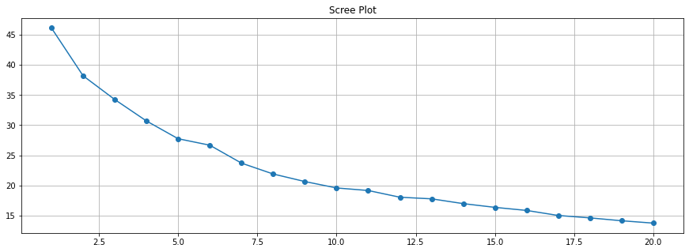

```python
# Plotting the above data in the form of a scree plot
fig,axes = plt.subplots(figsize=(15,5))
plt.plot(wss_df['Num_of_clusters'],wss_df['WSS'],marker='o')
plt.title('Scree Plot')
plt.grid(True);
```

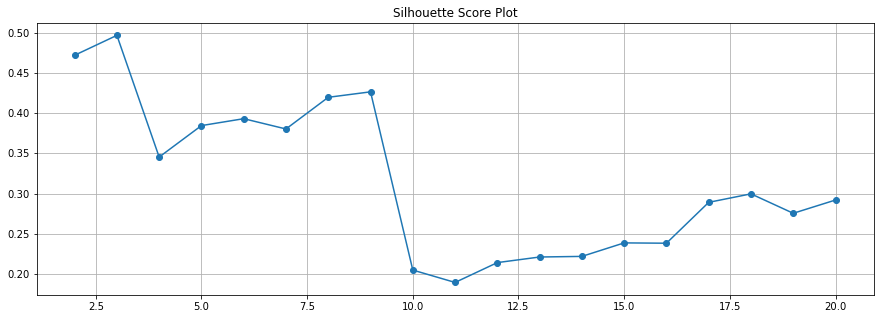

```python
from sklearn.metrics import silhouette_score
sil_score = []
for i in range(2,21):
    k_means = KMeans(n_clusters = i,random_state=1234)
    k_means.fit(toronto_grouped_clustering)
    clus = k_means.labels_
    sil_score.append(silhouette_score(X=toronto_grouped_clustering,labels = clus))
fig,axes = plt.subplots(figsize=(15,5))
plt.plot(range(2,21),sil_score,marker='o')
axes.set_title('Silhouette Score Plot')
plt.grid(True);
```

Let's create a new dataframe that includes the cluster as well as the top 10 venues for each neighborhood.

```python
# add clustering labels
neighborhoods_venues_sorted.insert(0, 'Cluster Labels', kmeans.labels_)
neighborhoods_venues_sorted.set_index('Neighborhood',inplace=True)
toronto_merged = toronto_data

# merge manhattan_grouped with manhattan_data to add latitude/longitude for each neighborhood
toronto_merged = toronto_merged.merge(neighborhoods_venues_sorted,left_on='NEIGHBOURHOOD',right_on='Neighborhood')

toronto_merged.head() # check the last columns!
```

|  | NEIGHBOURHOOD | POSTAL CODES | BOROUGH | Latitude | Longitude | Cluster Labels | 1st Most Common Venue | 2nd Most Common Venue | 3rd Most Common Venue | 4th Most Common Venue | 5th Most Common Venue | 6th Most Common Venue | 7th Most Common Venue | 8th Most Common Venue | 9th Most Common Venue | 10th Most Common Venue |
| --- | --- | --- | --- | --- | --- | --- | --- | --- | --- | --- | --- | --- | --- | --- | --- | --- |
| 0 | Adelaide | M5H | Downtown Toronto | 43.650571 | -79.384568 | 2 | Coffee Shop | Café | Sandwich Place | Clothing Store | Gym | Sushi Restaurant | Restaurant | Hotel | Steakhouse | Bank |
| 1 | Richmond | M5H | Downtown Toronto | 43.650571 | -79.384568 | 2 | Coffee Shop | Café | Sandwich Place | Clothing Store | Gym | Sushi Restaurant | Restaurant | Hotel | Steakhouse | Bank |
| 2 | Agincourt North | M1V | Scarborough | 43.815252 | -79.284577 | 0 | Playground | Park | Intersection | Women's Store | Dance Studio | Deli / Bodega | Department Store | Dessert Shop | Diner | Discount Store |
| 3 | L'Amoreaux East | M1V | Scarborough | 43.815252 | -79.284577 | 0 | Playground | Park | Intersection | Women's Store | Dance Studio | Deli / Bodega | Department Store | Dessert Shop | Diner | Discount Store |
| 4 | Milliken | M1V | Scarborough | 43.815252 | -79.284577 | 0 | Playground | Park | Intersection | Women's Store | Dance Studio | Deli / Bodega | Department Store | Dessert Shop | Diner | Discount Store |

Finally, let's visualize the resulting clusters

```python
# create map
map_clusters = folium.Map(location=[latitude, longitude], zoom_start=11)

# set color scheme for the clusters
x = np.arange(kclusters)
ys = [i + x + (i*x)**2 for i in range(kclusters)]
colors_array = cm.rainbow_r(np.linspace(0, 1, len(ys)))
rainbow = [colors.rgb2hex(i) for i in colors_array]

# add markers to the map
markers_colors = []
for lat, lon, poi, cluster in zip(toronto_merged['Latitude'], toronto_merged['Longitude'],
                                  toronto_merged['NEIGHBOURHOOD'], toronto_merged['Cluster Labels']):
    label = folium.Popup(str(poi) + ' Cluster ' + str(cluster), parse_html=True)
    folium.CircleMarker(
        [lat, lon],
        radius=7,
        popup=label,
        color=rainbow[cluster-1],
        fill=True,
        fill_color=rainbow[cluster-1],
        fill_opacity=0.1).add_to(map_clusters)

map_clusters
```

Make this Notebook Trusted to load map: File -> Trust Notebook

[interactive chart not shown]

## 5. Examine Clusters

Now, we can examine each cluster and determine the discriminating venue categories that distinguish each cluster. Based on the defining categories, you can then assign a name to each cluster.

```python
width = 40 # width of chart
height = 10 # height of chart

total_num_tiles = width * height # total number of tiles

print ('Total number of tiles is ', total_num_tiles)
```

```
Total number of tiles is  400
```

```python
waffle = toronto_merged['Cluster Labels'].value_counts().to_frame()
waffle.reset_index(inplace=True)
waffle.rename(columns={waffle.columns[0]:'Clusters'},inplace=True)
waffle
```

|  | Clusters | Cluster Labels |
| --- | --- | --- |
| 0 | 2 | 160 |
| 1 | 0 | 24 |
| 2 | 3 | 10 |
| 3 | 4 | 4 |
| 4 | 1 | 2 |

```python
# compute the proportion of each category with respect to the total
total_values = sum(waffle['Cluster Labels'])
category_proportions = [(float(value) / total_values) for value in waffle['Cluster Labels']]

# print out proportions
for i, proportion in enumerate(category_proportions):
    print(waffle.Clusters.values[i],':',proportion)
```

```
2 : 0.8
0 : 0.12
3 : 0.05
4 : 0.02
1 : 0.01
```

```python
# compute the number of tiles for each catagory
tiles_per_category = [round(proportion * total_num_tiles) for proportion in category_proportions]

# print out number of tiles per category
for i, tiles in enumerate(tiles_per_category):
    print (waffle.Clusters.values[i], ': ' , tiles)
```

```
2 :  320
0 :  48
3 :  20
4 :  8
1 :  4
```

```python
# initialize the waffle chart as an empty matrix
waffle_chart = np.zeros((height, width))

# define indices to loop through waffle chart
category_index = 0
tile_index = 0

# populate the waffle chart
for col in range(width):
    for row in range(height):
        tile_index += 1

        # if the number of tiles populated for the current category is equal to its corresponding allocated tiles...
        if tile_index > sum(tiles_per_category[0:category_index]):
            # ...proceed to the next category
            category_index += 1

        # set the class value to an integer, which increases with class
        waffle_chart[row, col] = category_index

print ('Waffle chart populated!')
```

```
Waffle chart populated!
```

```
   Clusters  Cluster Labels
0         2             160
1         0              24
2         3              10
3         4               4
4         1               2
```

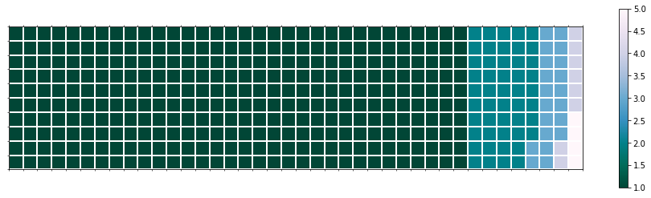

```python
# instantiate a new figure object
fig = plt.figure()

# use matshow to display the waffle chart
colormap = plt.cm.PuBuGn_r
plt.matshow(waffle_chart, cmap=colormap)
plt.colorbar()

# get the axis
ax = plt.gca()

# set minor ticks
ax.set_xticks(np.arange(-.5, (width), 1), minor=True)
ax.set_yticks(np.arange(-.5, (height), 1), minor=True)

# add gridlines based on minor ticks
ax.grid(which='minor', color='w', linestyle='-', linewidth=2)
print(waffle)
plt.xticks([])
plt.yticks([])
plt.show()
```

```python
from wordcloud import WordCloud, STOPWORDS

print ('Wordcloud is imported!')
```

```
Wordcloud is imported!
```

#### Cluster 1

```python
cluster1 = toronto_merged.loc[toronto_merged['Cluster Labels'] == 0, toronto_merged.columns[[1] + list(range(5, toronto_merged.shape[1]))]]
cluster1
```

|  | POSTAL CODES | Cluster Labels | 1st Most Common Venue | 2nd Most Common Venue | 3rd Most Common Venue | 4th Most Common Venue | 5th Most Common Venue | 6th Most Common Venue | 7th Most Common Venue | 8th Most Common Venue | 9th Most Common Venue | 10th Most Common Venue |
| --- | --- | --- | --- | --- | --- | --- | --- | --- | --- | --- | --- | --- |
| 2 | M1V | 0 | Playground | Park | Intersection | Women's Store | Dance Studio | Deli / Bodega | Department Store | Dessert Shop | Diner | Discount Store |
| 3 | M1V | 0 | Playground | Park | Intersection | Women's Store | Dance Studio | Deli / Bodega | Department Store | Dessert Shop | Diner | Discount Store |
| 4 | M1V | 0 | Playground | Park | Intersection | Women's Store | Dance Studio | Deli / Bodega | Department Store | Dessert Shop | Diner | Discount Store |
| 5 | M1V | 0 | Playground | Park | Intersection | Women's Store | Dance Studio | Deli / Bodega | Department Store | Dessert Shop | Diner | Discount Store |
| 37 | M4J | 0 | Park | Convenience Store | Home Service | Women's Store | Diner | Dance Studio | Deli / Bodega | Department Store | Dessert Shop | Discount Store |
| 38 | M4J | 0 | Park | Convenience Store | Home Service | Women's Store | Diner | Dance Studio | Deli / Bodega | Department Store | Dessert Shop | Discount Store |
| 47 | M6E | 0 | Park | Women's Store | Pool | Diner | Cupcake Shop | Dance Studio | Deli / Bodega | Department Store | Dessert Shop | Discount Store |
| 88 | M3K | 0 | Park | Airport | Bus Stop | Playground | Women's Store | Diner | Cupcake Shop | Dance Studio | Deli / Bodega | Department Store |
| 132 | M6C | 0 | Trail | Park | Hockey Arena | Field | Women's Store | Dance Studio | Deli / Bodega | Department Store | Dessert Shop | Diner |
| 135 | M9R | 0 | Bus Line | Pizza Place | Park | Sandwich Place | Cupcake Shop | Dance Studio | Deli / Bodega | Department Store | Dessert Shop | Women's Store |
| 136 | M9R | 0 | Bus Line | Pizza Place | Park | Sandwich Place | Cupcake Shop | Dance Studio | Deli / Bodega | Department Store | Dessert Shop | Women's Store |
| 137 | M9R | 0 | Bus Line | Pizza Place | Park | Sandwich Place | Cupcake Shop | Dance Studio | Deli / Bodega | Department Store | Dessert Shop | Women's Store |
| 138 | M9R | 0 | Bus Line | Pizza Place | Park | Sandwich Place | Cupcake Shop | Dance Studio | Deli / Bodega | Department Store | Dessert Shop | Women's Store |
| 156 | M6L | 0 | Park | Bakery | Basketball Court | Construction & Landscaping | Women's Store | Distribution Center | Department Store | Dessert Shop | Diner | Discount Store |
| 157 | M6L | 0 | Park | Bakery | Basketball Court | Construction & Landscaping | Women's Store | Distribution Center | Department Store | Dessert Shop | Diner | Discount Store |
| 158 | M6L | 0 | Park | Bakery | Basketball Court | Construction & Landscaping | Women's Store | Distribution Center | Department Store | Dessert Shop | Diner | Discount Store |
| 161 | M8X | 0 | Park | River | Women's Store | Cuban Restaurant | Drugstore | Donut Shop | Doner Restaurant | Dog Run | Distribution Center | Discount Store |
| 162 | M8X | 0 | Park | River | Women's Store | Cuban Restaurant | Drugstore | Donut Shop | Doner Restaurant | Dog Run | Distribution Center | Discount Store |
| 163 | M8X | 0 | Park | River | Women's Store | Cuban Restaurant | Drugstore | Donut Shop | Doner Restaurant | Dog Run | Distribution Center | Discount Store |
| 166 | M2M | 0 | Park | Women's Store | Cuban Restaurant | Eastern European Restaurant | Drugstore | Donut Shop | Doner Restaurant | Dog Run | Distribution Center | Discount Store |
| 177 | M3A | 0 | Park | Food & Drink Shop | Fast Food Restaurant | Women's Store | Diner | Dance Studio | Deli / Bodega | Department Store | Dessert Shop | Distribution Center |
| 181 | M4W | 0 | Park | Playground | Trail | Cupcake Shop | Dance Studio | Deli / Bodega | Department Store | Dessert Shop | Diner | Women's Store |
| 196 | M9N | 0 | Jewelry Store | Park | Women's Store | Dance Studio | Deli / Bodega | Department Store | Dessert Shop | Diner | Discount Store | Distribution Center |
| 199 | M2P | 0 | Park | Convenience Store | Women's Store | Discount Store | Dance Studio | Deli / Bodega | Department Store | Dessert Shop | Diner | Distribution Center |

```python
cluster1_common = cluster1.iloc[:,2:]
unique = []
for i in cluster1_common.columns:
    unique.append(cluster1_common[i].values.tolist())
```

```python
cluster1_list = list(itertools.chain.from_iterable(unique))
```

```python
stopwords = set(STOPWORDS)
```

```python
cluster = WordCloud(background_color='white',
    max_words=300,
    stopwords=stopwords)
```

```python
cluster.generate(" ".join(cluster1_list))
```

```
<wordcloud.wordcloud.WordCloud at 0x21e4fedaa30>
```

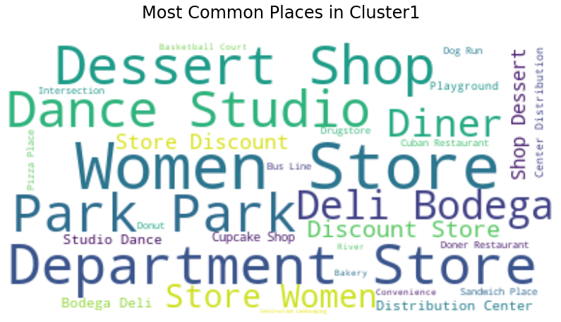

```python
# display the cloud
fig = plt.figure()
fig.set_figwidth(14)
fig.set_figheight(18)

plt.imshow(cluster, interpolation='bilinear')
plt.axis('off')
plt.title('Most Common Places in Cluster1\n',fontsize=24)
plt.show()
```

#### Cluster 2

```python
cluster2 = toronto_merged.loc[toronto_merged['Cluster Labels'] == 1, toronto_merged.columns[[1] + list(range(5, toronto_merged.shape[1]))]]
cluster2
```

|  | POSTAL CODES | Cluster Labels | 1st Most Common Venue | 2nd Most Common Venue | 3rd Most Common Venue | 4th Most Common Venue | 5th Most Common Venue | 6th Most Common Venue | 7th Most Common Venue | 8th Most Common Venue | 9th Most Common Venue | 10th Most Common Venue |
| --- | --- | --- | --- | --- | --- | --- | --- | --- | --- | --- | --- | --- |
| 164 | M4T | 1 | Restaurant | Women's Store | Escape Room | Eastern European Restaurant | Drugstore | Donut Shop | Doner Restaurant | Dog Run | Distribution Center | Discount Store |
| 165 | M4T | 1 | Restaurant | Women's Store | Escape Room | Eastern European Restaurant | Drugstore | Donut Shop | Doner Restaurant | Dog Run | Distribution Center | Discount Store |

```python
cluster2_common = cluster2.iloc[:,2:]
unique = []
for i in cluster2_common.columns:
    unique.append(cluster2_common[i].values.tolist())

cluster2_list = list(itertools.chain.from_iterable(unique))
```

```python
cluster.generate_from_text(" ".join(cluster2_list))
```

```
<wordcloud.wordcloud.WordCloud at 0x21e4fedaa30>
```

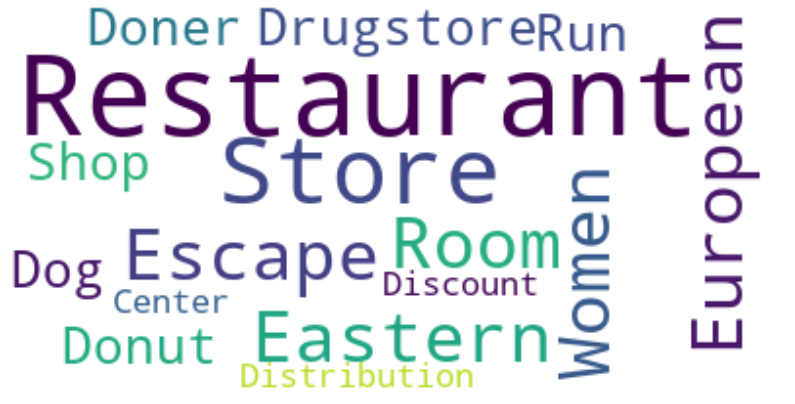

```python
# display the cloud
fig = plt.figure()
fig.set_figwidth(14)
fig.set_figheight(18)

plt.imshow(cluster, interpolation='bilinear')
plt.axis('off')
plt.show()
```

#### Cluster 3

```python
cluster3 = toronto_merged.loc[toronto_merged['Cluster Labels'] == 2, toronto_merged.columns[[1] + list(range(5, toronto_merged.shape[1]))]]
cluster3
```

|  | POSTAL CODES | Cluster Labels | 1st Most Common Venue | 2nd Most Common Venue | 3rd Most Common Venue | 4th Most Common Venue | 5th Most Common Venue | 6th Most Common Venue | 7th Most Common Venue | 8th Most Common Venue | 9th Most Common Venue | 10th Most Common Venue |
| --- | --- | --- | --- | --- | --- | --- | --- | --- | --- | --- | --- | --- |
| 0 | M5H | 2 | Coffee Shop | Café | Sandwich Place | Clothing Store | Gym | Sushi Restaurant | Restaurant | Hotel | Steakhouse | Bank |
| 1 | M5H | 2 | Coffee Shop | Café | Sandwich Place | Clothing Store | Gym | Sushi Restaurant | Restaurant | Hotel | Steakhouse | Bank |
| 6 | M1S | 2 | Latin American Restaurant | Lounge | Chinese Restaurant | Breakfast Spot | Dance Studio | Eastern European Restaurant | Drugstore | Donut Shop | Doner Restaurant | Dog Run |
| 7 | M9V | 2 | Grocery Store | Indie Movie Theater | Pharmacy | Pizza Place | Sandwich Place | Fast Food Restaurant | Beer Store | Coffee Shop | Garden Center | Dog Run |
| 8 | M9V | 2 | Grocery Store | Indie Movie Theater | Pharmacy | Pizza Place | Sandwich Place | Fast Food Restaurant | Beer Store | Coffee Shop | Garden Center | Dog Run |
| 9 | M9V | 2 | Grocery Store | Indie Movie Theater | Pharmacy | Pizza Place | Sandwich Place | Fast Food Restaurant | Beer Store | Coffee Shop | Garden Center | Dog Run |
| 10 | M9V | 2 | Grocery Store | Indie Movie Theater | Pharmacy | Pizza Place | Sandwich Place | Fast Food Restaurant | Beer Store | Coffee Shop | Garden Center | Dog Run |
| 11 | M9V | 2 | Grocery Store | Indie Movie Theater | Pharmacy | Pizza Place | Sandwich Place | Fast Food Restaurant | Beer Store | Coffee Shop | Garden Center | Dog Run |
| 12 | M9V | 2 | Grocery Store | Indie Movie Theater | Pharmacy | Pizza Place | Sandwich Place | Fast Food Restaurant | Beer Store | Coffee Shop | Garden Center | Dog Run |
| 13 | M9V | 2 | Grocery Store | Indie Movie Theater | Pharmacy | Pizza Place | Sandwich Place | Fast Food Restaurant | Beer Store | Coffee Shop | Garden Center | Dog Run |
| 14 | M9V | 2 | Grocery Store | Indie Movie Theater | Pharmacy | Pizza Place | Sandwich Place | Fast Food Restaurant | Beer Store | Coffee Shop | Garden Center | Dog Run |
| 15 | M8W | 2 | Pizza Place | Coffee Shop | Skating Rink | Sandwich Place | Pub | Athletics & Sports | College Rec Center | College Stadium | College Arts Building | Donut Shop |
| 16 | M8W | 2 | Pizza Place | Coffee Shop | Skating Rink | Sandwich Place | Pub | Athletics & Sports | College Rec Center | College Stadium | College Arts Building | Donut Shop |
| 17 | M3H | 2 | Coffee Shop | Bank | Grocery Store | Pharmacy | Sandwich Place | Diner | Bridal Shop | Intersection | Ice Cream Shop | Sushi Restaurant |
| 18 | M3H | 2 | Coffee Shop | Bank | Grocery Store | Pharmacy | Sandwich Place | Diner | Bridal Shop | Intersection | Ice Cream Shop | Sushi Restaurant |
| 19 | M3H | 2 | Coffee Shop | Bank | Grocery Store | Pharmacy | Sandwich Place | Diner | Bridal Shop | Intersection | Ice Cream Shop | Sushi Restaurant |
| 20 | M5V | 2 | Airport Lounge | Airport Service | Airport Terminal | Harbor / Marina | Boat or Ferry | Coffee Shop | Sculpture Garden | Airport | Airport Food Court | Airport Gate |
| 21 | M5V | 2 | Airport Lounge | Airport Service | Airport Terminal | Harbor / Marina | Boat or Ferry | Coffee Shop | Sculpture Garden | Airport | Airport Food Court | Airport Gate |
| 22 | M5V | 2 | Airport Lounge | Airport Service | Airport Terminal | Harbor / Marina | Boat or Ferry | Coffee Shop | Sculpture Garden | Airport | Airport Food Court | Airport Gate |
| 23 | M5V | 2 | Airport Lounge | Airport Service | Airport Terminal | Harbor / Marina | Boat or Ferry | Coffee Shop | Sculpture Garden | Airport | Airport Food Court | Airport Gate |
| 24 | M5V | 2 | Airport Lounge | Airport Service | Airport Terminal | Harbor / Marina | Boat or Ferry | Coffee Shop | Sculpture Garden | Airport | Airport Food Court | Airport Gate |
| 25 | M5V | 2 | Airport Lounge | Airport Service | Airport Terminal | Harbor / Marina | Boat or Ferry | Coffee Shop | Sculpture Garden | Airport | Airport Food Court | Airport Gate |
| 26 | M5V | 2 | Airport Lounge | Airport Service | Airport Terminal | Harbor / Marina | Boat or Ferry | Coffee Shop | Sculpture Garden | Airport | Airport Food Court | Airport Gate |
| 27 | M2K | 2 | Café | Japanese Restaurant | Chinese Restaurant | Bank | Women's Store | Discount Store | Department Store | Dessert Shop | Diner | Distribution Center |
| 28 | M5M | 2 | Coffee Shop | Restaurant | Sandwich Place | Italian Restaurant | Sushi Restaurant | Comfort Food Restaurant | Café | Pharmacy | Pizza Place | Butcher |
| 29 | M5M | 2 | Coffee Shop | Restaurant | Sandwich Place | Italian Restaurant | Sushi Restaurant | Comfort Food Restaurant | Café | Pharmacy | Pizza Place | Butcher |
| 30 | M5E | 2 | Coffee Shop | Cocktail Bar | Sandwich Place | Bakery | Beer Bar | Vegetarian / Vegan Restaurant | Farmers Market | Seafood Restaurant | Spa | Bistro |
| 31 | M1N | 2 | Skating Rink | Farm | General Entertainment | College Stadium | Café | Women's Store | Discount Store | Deli / Bodega | Department Store | Dessert Shop |
| 32 | M1N | 2 | Skating Rink | Farm | General Entertainment | College Stadium | Café | Women's Store | Discount Store | Deli / Bodega | Department Store | Dessert Shop |
| 33 | M9C | 2 | Beer Store | Pet Store | Liquor Store | Café | Pizza Place | Pharmacy | Coffee Shop | College Stadium | Dance Studio | Drugstore |

[output cut: 130 more lines]

```python
cluster3_common = cluster3.iloc[:,2:]
unique = []
for i in cluster3_common.columns:
    unique.append(cluster3_common[i].values.tolist())

cluster3_list = list(itertools.chain.from_iterable(unique))
```

```python
cluster.generate_from_text(" ".join(cluster3_list))
```

```
<wordcloud.wordcloud.WordCloud at 0x21e4fedaa30>
```

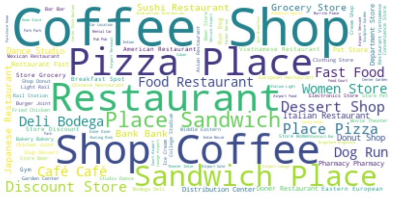

```python
# display the cloud
fig = plt.figure()
fig.set_figwidth(14)
fig.set_figheight(18)

plt.imshow(cluster, interpolation='bilinear')
plt.axis('off')
plt.show()
```

#### Cluster 4

```python
cluster4 = toronto_merged.loc[toronto_merged['Cluster Labels'] == 3, toronto_merged.columns[[1] + list(range(5, toronto_merged.shape[1]))]]
cluster4
```

|  | POSTAL CODES | Cluster Labels | 1st Most Common Venue | 2nd Most Common Venue | 3rd Most Common Venue | 4th Most Common Venue | 5th Most Common Venue | 6th Most Common Venue | 7th Most Common Venue | 8th Most Common Venue | 9th Most Common Venue | 10th Most Common Venue |
| --- | --- | --- | --- | --- | --- | --- | --- | --- | --- | --- | --- | --- |
| 92 | M9M | 3 | Paper / Office Supplies Store | Baseball Field | Cupcake Shop | Electronics Store | Eastern European Restaurant | Drugstore | Donut Shop | Doner Restaurant | Dog Run | Distribution Center |
| 93 | M9M | 3 | Paper / Office Supplies Store | Baseball Field | Cupcake Shop | Electronics Store | Eastern European Restaurant | Drugstore | Donut Shop | Doner Restaurant | Dog Run | Distribution Center |
| 123 | M8Y | 3 | Baseball Field | Women's Store | Ethiopian Restaurant | Electronics Store | Eastern European Restaurant | Drugstore | Donut Shop | Doner Restaurant | Dog Run | Distribution Center |
| 124 | M8Y | 3 | Baseball Field | Women's Store | Ethiopian Restaurant | Electronics Store | Eastern European Restaurant | Drugstore | Donut Shop | Doner Restaurant | Dog Run | Distribution Center |
| 125 | M8Y | 3 | Baseball Field | Women's Store | Ethiopian Restaurant | Electronics Store | Eastern European Restaurant | Drugstore | Donut Shop | Doner Restaurant | Dog Run | Distribution Center |
| 126 | M8Y | 3 | Baseball Field | Women's Store | Ethiopian Restaurant | Electronics Store | Eastern European Restaurant | Drugstore | Donut Shop | Doner Restaurant | Dog Run | Distribution Center |
| 127 | M8Y | 3 | Baseball Field | Women's Store | Ethiopian Restaurant | Electronics Store | Eastern European Restaurant | Drugstore | Donut Shop | Doner Restaurant | Dog Run | Distribution Center |
| 128 | M8Y | 3 | Baseball Field | Women's Store | Ethiopian Restaurant | Electronics Store | Eastern European Restaurant | Drugstore | Donut Shop | Doner Restaurant | Dog Run | Distribution Center |
| 129 | M8Y | 3 | Baseball Field | Women's Store | Ethiopian Restaurant | Electronics Store | Eastern European Restaurant | Drugstore | Donut Shop | Doner Restaurant | Dog Run | Distribution Center |
| 130 | M8Y | 3 | Baseball Field | Women's Store | Ethiopian Restaurant | Electronics Store | Eastern European Restaurant | Drugstore | Donut Shop | Doner Restaurant | Dog Run | Distribution Center |

```python
cluster4_common = cluster4.iloc[:,2:]
unique = []
for i in cluster4_common.columns:
    unique.append(cluster4_common[i].values.tolist())

cluster4_list = list(itertools.chain.from_iterable(unique))
```

```python
cluster.generate_from_text(" ".join(cluster4_list))
```

```
<wordcloud.wordcloud.WordCloud at 0x21e4fedaa30>
```

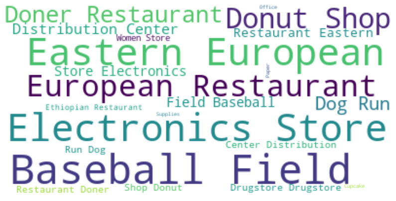

```python
# display the cloud
fig = plt.figure()
fig.set_figwidth(14)
fig.set_figheight(18)

plt.imshow(cluster, interpolation='bilinear')
plt.axis('off')
plt.show()
```

#### Cluster 5

```python
cluster5 = toronto_merged.loc[toronto_merged['Cluster Labels'] == 4, toronto_merged.columns[[1] + list(range(5, toronto_merged.shape[1]))]]
cluster5
```

|  | POSTAL CODES | Cluster Labels | 1st Most Common Venue | 2nd Most Common Venue | 3rd Most Common Venue | 4th Most Common Venue | 5th Most Common Venue | 6th Most Common Venue | 7th Most Common Venue | 8th Most Common Venue | 9th Most Common Venue | 10th Most Common Venue |
| --- | --- | --- | --- | --- | --- | --- | --- | --- | --- | --- | --- | --- |
| 64 | M9B | 4 | Middle Eastern Restaurant | Women's Store | Coffee Shop | Electronics Store | Eastern European Restaurant | Drugstore | Donut Shop | Doner Restaurant | Dog Run | Distribution Center |
| 65 | M9B | 4 | Middle Eastern Restaurant | Women's Store | Coffee Shop | Electronics Store | Eastern European Restaurant | Drugstore | Donut Shop | Doner Restaurant | Dog Run | Distribution Center |
| 66 | M9B | 4 | Middle Eastern Restaurant | Women's Store | Coffee Shop | Electronics Store | Eastern European Restaurant | Drugstore | Donut Shop | Doner Restaurant | Dog Run | Distribution Center |
| 67 | M9B | 4 | Middle Eastern Restaurant | Women's Store | Coffee Shop | Electronics Store | Eastern European Restaurant | Drugstore | Donut Shop | Doner Restaurant | Dog Run | Distribution Center |

```python
cluster5_common = cluster5.iloc[:,2:]
unique = []
for i in cluster5_common.columns:
    unique.append(cluster5_common[i].values.tolist())

cluster5_list = list(itertools.chain.from_iterable(unique))
```

```python
cluster.generate_from_text(" ".join(cluster5_list))
```

```
<wordcloud.wordcloud.WordCloud at 0x21e4fedaa30>
```

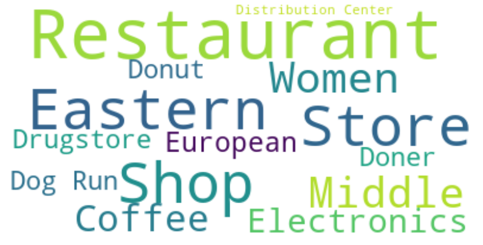

```python
# display the cloud
fig = plt.figure()
fig.set_figwidth(14)
fig.set_figheight(18)

plt.imshow(cluster, interpolation='bilinear')
plt.axis('off')
plt.show()
```